# Machine learning study (neural network only)

Matthew Fredericks

24th September 2019

# Setup

```r
compile_from_scratch = FALSE #set TRUE if you have new patient metric data to create new dataframe

if (compile_from_scratch==FALSE){
  wd1 = getwd() #directory of patient metrics data
  metricdata_filename = "metricdata_upc.txt" #"metricdata_bpc.txt" #"metricdata_pmime.txt"
  all = read.delim(metricdata_filename)
  all$schizophrenia = as.factor(all$schizophrenia)
}

if (compile_from_scratch==TRUE){

  hpats = c('6140', '6227', '6232', '6255', '6383a', '6383b', '6395', '6396a', '6396b', '7577', '7890') #healthy patient ID
  spats = c('6527', '7063', '7574', '7608', '7634', '7771', '7943') #schizophrenia patient ID

  list <- vector(mode="list", length(hpats)+length(spats)) #initialise list of dataframes
  count <- 0

  for (pat in hpats){
    count <- count + 1
    names(list)[count] <- pat
    filename <- #paste(letter, 'metrics_pat', pat, '.txt', sep="")
    list[[count]] <- read.delim(filename, header=FALSE) #import data
  }

  for (pat in spats){
    count <- count + 1
    names(list)[count] <- pat
    filename <- #paste(letter, 'metrics_pat', pat, '.txt', sep="")
    list[[count]] <- read.delim(filename, header=FALSE) #import data
  }

  sch = c(rep(0,length(hpats)),rep(1,length(spats))) #schizophrenia indicator

  for (i in 1:length(list)){ #for each patient
    data1 <- list[[i]]       #retrieve dataframe
    data <- na.omit(data1)   #listwise deletion of missing values
    num_omitted <- dim(data1)[1]-dim(data)[1] #number of rows deleted
    if (num_omitted != 0){
      cat(num_omitted, "entries were deleted for patient", names(list)[i],
          "(batch:", batch, ") due to NAs \n")
    }
    data <- data[,-c(3,8,18,19)]   #remove out degree/strength mean as collinear with in degree/strength and local efficiency mean/sd (collinear with clustering coef)
    data <- cbind(data, rep(0, dim(data)[1])) #initialise cost efficiency variable
    data <- cbind(data, rep(names(list)[i], dim(data)[1])) #create subject ID variable
    data <- cbind(data, factor(rep(sch[i], dim(data)[1]))) #create schizophrenia outcome variable
    colnames(data) <- c("in_degree_mean",
                       "in_degree_sd",
    #                  "out_degree_mean",
                       "out_degree_sd",
                       "degree_difference_sd",
                       "in_strength_mean",
                       "in_strength_sd",
    #                  "out_strength_mean",
                       "out_strength_sd",
                       "strength_difference_sd",
                       "edge_betweenness_mean",
                       "edge_betweenness_sd",
                       "node_betweenness_mean",
                       "node_betweenness_sd",
                       "density",
                       "wiring_cost",
                       "global_efficiency",
     #                  "local_efficiency_mean",
     #                  "local_efficiency_sd",
                       "modularity",
                       "clustering_coefficient_mean",
                       "clustering_coefficient_sd",
                       "assortativity_oi",
                       "assortativity_io",
                       "assortativity_oo",
                       "assortativity_ii",
                       "cost_efficiency",
                       "subject_id",
                       "schizophrenia")
    data <- as.data.frame(data)
    list[[i]] <- data #update list
  }

  all <- Reduce(function(dtf1, dtf2) merge(dtf1, dtf2, all=TRUE), list) #create merged dataset
  colnames(all) <- colnames(data)
  n <- dim(all)[1]

}

n <- dim(all)[1]
m <- 22 #num_metrics not including created variables costefficiency, subjectid, schizophrenia
```

# Machine Learning

In order to assess performance of classification algorithms, we must set aside an independent testing dataset that does not overlap with the training dataset used to train the algorithm. Therefore we should note that we cannot simply standardise all the data per patient like in the exploratory data analysis. This is because in order to best simulate operational conditions, the data used to train the algorithms should contain **NO** information about the data used to test the algorithms.

This means we must standardise the testing set using the same scale as the training set. As we are essentially treating the testing data as unseen, it no longer makes sense to standardise each patient individually, as this would require finding the vector of training means/std. devs for each patient and scaling this patient’s testing data by the same quantity (which implicitly assumes this patient is not unseen). Thus we standardise patients together, despite this meaning potential accuracy losses due to variation in experimental conditions per patient etc.

```r
process_data <- function(train_inds, #indexes for training subset
                         test_inds){  #indexes for testing subset

  train <- all[train_inds,]      #training dataset
  test <- all[test_inds,]        #testing dataset

  #standardise the predictors based on TRAIN data
  trainmeans <- attr(scale(train[,1:m]),"scaled:center") #extract train means
  trainsds <- attr(scale(train[,1:m]),"scaled:scale")    #extract train std. devs
  train[,1:m] <- scale(train[,1:m])                     #standardise train data
  test[,1:m] <- scale(test[,1:m],                       #standardise test data
                       center=trainmeans,                 #use training means
                       scale=trainsds)                    #use training std. devs

  #cost efficiency
  ce <- train[,15]-train[,14] #variable based on train data (global efficiency - wiring cost)
  cemean <- mean(ce)
  cesd <- sd(ce)
  train[,m+1] <- scale(ce)
  test[,m+1] <- scale(test[,15]-test[,14], center=cemean, scale=cesd)
  return(list(train, test))
}




kfold <- function(k,          #number of folds
                  modelpred,  #classification function which predicts labels of inputs given training data
                  par){        #optional parameters needed for modelpred function

  train_acc <- vector("numeric", k)  #initialise vector of accuracy on train data per fold
  test_acc <- vector("numeric", k)   #initialise vector of accuracy on test data per fold
  train_coefs <- vector("list", k)   #initialise list of coefficient values per fold

  randseq <- sample(n, n)    #initialise random sequence (unchanged for all folds)
  size <- floor(n/k)         #size of test set for each fold

  for (fold in 1:k){         #now fold:
    test_inds <- randseq[((fold-1)*size+1):(fold*size)] #take (progressive) slices as testing
    train_inds <- (1:n)[-test_inds] #remaining indices for training

    datalist <- process_data(train_inds, test_inds) #construct standardised datasets using these indices
    train <- datalist[[1]]       #assign training data
    test <- datalist[[2]]        #assign testing data
    train_y <- train[,m+3]        #training labels
    train_x <- train[,-c(m+2,m+3)] #training inputs
    test_y <- test[,m+3]          #testing labels
    test_x <- test[,-c(m+2,m+3)]   #testing inputs

    mtrain <- modelpred(train_x, train_x, train_y, par) #predict labels for training inputs
    mtest <- modelpred(test_x, train_x, train_y, par)   #predict labels for testing inputs

    train_preds <- mtrain[[1]] #obtain predictions for training inputs
    train_coefs[[fold]] <- mtrain[[2]] #optional model coefficients
    test_preds <- mtest[[1]] #obtain predictions for testing inputs

    train_acc[fold] <- sum(train_y==train_preds)/length(train_y) #compare with actual y for acc.
    test_acc[fold] <- sum(test_y==test_preds)/length(test_y)     #compare with actual y for acc.
  }
  means <- c(mean(train_acc), mean(test_acc)) #average accuracies over all the folds
  coefs <- 0
  for (i in 1:k){coefs <- coefs + train_coefs[[i]]}
  coefs <- coefs/k #average optional model coefficients over all the folds
  return(list(means, coefs, train_acc, test_acc)) #output cross-validated train and test accuracies, and mean coef vals
}
```

```r
#set number of folds
folds <- 5
```

We might instead decide to use individual patients for training/testing. This way we can ensure an individual’s data is not being used for both training and testing.

```r
hpats = c('6140', '6227', '6232', '6255', '6383a', '6383b', '6395', '6396a', '6396b', '7577', '7890') #healthy patient ID
spats = c('6527', '7063', '7574', '7608', '7634', '7771', '7943') #schizophrenia patient ID
idlist <- c(hpats,spats)


kfold2 <- function(modelpred,  #classification function which predicts labels of inputs given training data
                  par){        #optional parameters needed for modelpred function

  #######################################  NEW PART  #################################
  #each fold is a different patient
  k <- length(idlist)
  train_acc <- vector("numeric", k)  #initialise vector of accuracy on train data per fold
  test_acc <- vector("numeric", k)   #initialise vector of accuracy on test data per fold
  train_coefs <- vector("list", k)   #initialise list of coefficient values per fold

  for (fold in 1:k){         #now fold:
    pat <- idlist[k] #get patient id to test on
    test_inds <- which(all$subject_id==pat) #indices in data that match this id
    train_inds <- which(all$subject_id!=pat) #indices that don't match
  ####################################################################################

    datalist <- process_data(train_inds, test_inds) #construct standardised datasets using these indices
    train <- datalist[[1]]       #assign training data
    test <- datalist[[2]]        #assign testing data
    train_y <- train[,m+3]        #training labels
    train_x <- train[,-c(m+2,m+3)] #training inputs
    test_y <- test[,m+3]          #testing labels
    test_x <- test[,-c(m+2,m+3)]   #testing inputs

    mtrain <- modelpred(train_x, train_x, train_y, par) #predict labels for training inputs
    mtest <- modelpred(test_x, train_x, train_y, par)   #predict labels for testing inputs

    train_preds <- mtrain[[1]] #obtain predictions for training inputs
    train_coefs[[fold]] <- mtrain[[2]] #optional model coefficients
    test_preds <- mtest[[1]] #obtain predictions for testing inputs

    train_acc[fold] <- sum(train_y==train_preds)/length(train_y) #compare with actual y for acc.
    test_acc[fold] <- sum(test_y==test_preds)/length(test_y)     #compare with actual y for acc.
  }
  means <- c(mean(train_acc), mean(test_acc)) #average accuracies over all the folds
  coefs <- 0
  for (i in 1:k){coefs <- coefs + train_coefs[[i]]}
  coefs <- coefs/k #average optional model coefficients over all the folds
  return(list(means, coefs, train_acc, test_acc)) #output cross-validated train and test accuracies, and mean coef vals
}
```

## Artificial neural network

```r
library(nnet)

nn_pred <- function(inputs, train_x, train_y,
                    par){ #par = list(size, MaxNWts, maxit, num_tries)
  num_tries <- par[[4]]
  nn_list <- vector("list", num_tries) #initialise list of nns
  vals <- vector("numeric", num_tries) #initialise vector of final optimisation vals
  for (i in 1:num_tries){
    nn <- nnet(train_y ~., data=train_x,
               size=par[[1]], MaxNWts=par[[2]], maxit=par[[3]], trace=FALSE)
    nn_list[[i]] <- nn #record this nn
    vals[i] <- nn$value #record final optimisation value
  }
  min <- which(vals==min(vals)) #index of nn with the lowest final optimisation value
  bestnn <- nn_list[[min]] #retrieve this nn
  preds <- predict(bestnn, inputs, type="class")
  coefs <- NA
  return(list(preds, coefs))
}
```

```r
pars <- c(seq(1,10,1))
x <- length(pars)
trainaccs <- vector("numeric", x)
testaccs <- vector("numeric", x)
trainaccs2 <- vector("numeric", x)
testaccs2 <- vector("numeric", x)

count = 0
for (par in pars){
  count = count+1
  nn <- kfold(k=folds, modelpred=nn_pred, par=list(par,5000,300,10))
  trainaccs[count] <- nn[[1]][1]
  testaccs[count] <- nn[[1]][2]

  nn2 <- kfold2(modelpred=nn_pred, par=list(par,5000,300,10))
  trainaccs2[count] <- nn2[[1]][1]
  testaccs2[count] <- nn2[[1]][2]

}
```

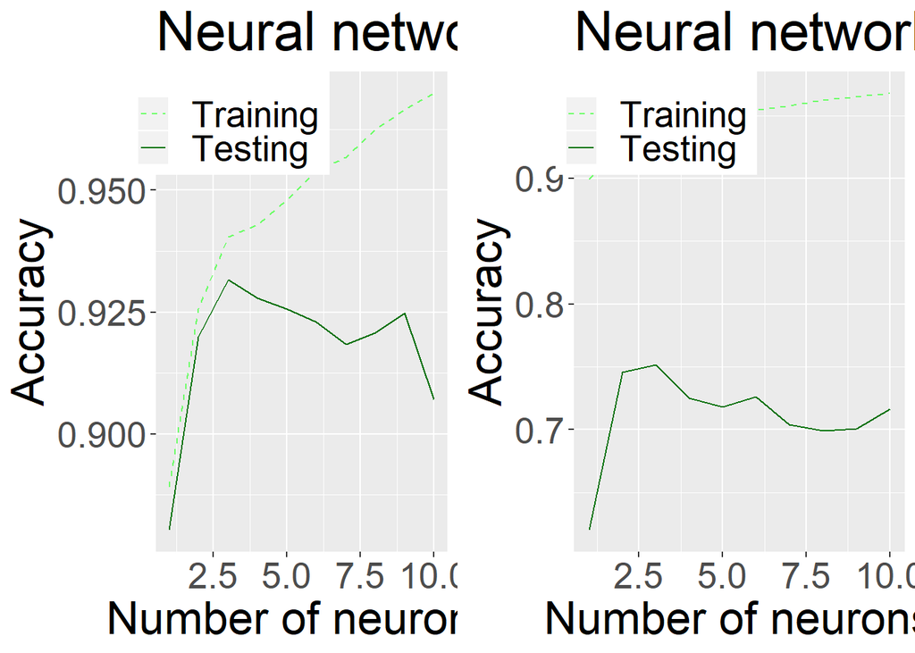

```r
library(ggplot2)
library(gridExtra)
library(reshape)

plot1 <- ggplot(melt(as.data.frame(cbind(pars, trainaccs, testaccs)), id.vars="pars")) +
  geom_line(aes(x=pars, y=value, col=variable, linetype=variable)) +
  ggtitle("Neural network parameter optimisation") +
  xlab("Number of neurons") +
  ylab("Accuracy") +
  scale_colour_manual(values=c("#6bff66","#007005"), labels=c("Training", "Testing")) +
  scale_linetype_manual(values=c(2, 1), labels=c("Training","Testing")) +
  theme(text = element_text(size=25),
        legend.position=c(.25, .9), legend.title=element_blank())


plot2 <- ggplot(melt(as.data.frame(cbind(pars, trainaccs2, testaccs2)), id.vars="pars")) +
  geom_line(aes(x=pars, y=value, col=variable, linetype=variable)) +
  ggtitle("Neural network parameter optimisation (per patient testing)") +
  xlab("Number of neurons") +
  ylab("Accuracy") +
  scale_colour_manual(values=c("#6bff66","#007005"), labels=c("Training", "Testing")) +
  scale_linetype_manual(values=c(2, 1), labels=c("Training","Testing")) +
  theme(text = element_text(size=25),
        legend.position=c(.25, .9), legend.title=element_blank())

grid.arrange(plot1, plot2, ncol=2)
```

```r
#ggsave("nnopt.png",grid.arrange(plot1, plot2, plot3, ncol=3),height=7,width=15)
```

```r
parmax <- pars[which(testaccs==max(testaccs))]
cat("The optimal number of neurons is", parmax, "\n")
```

```
## The optimal number of neurons is 3
```

```r
parmax2 <- pars[which(testaccs2==max(testaccs2))]
cat("The optimal number of neurons (per patient testing) is", parmax2, "\n")
```

```
## The optimal number of neurons (per patient testing) is 3
```

```r
nn <- kfold(k=folds,
      modelpred=nn_pred,
      par=list(parmax,    #size (number of neurons)
               5000, #MaxNWts
               300,  #maxit
               10))  #number of retries

nn2 <- kfold2(modelpred=nn_pred,
              par=list(parmax2,    #size (number of neurons)
                       5000, #MaxNWts
                       300,  #maxit
                       10))  #number of retries
```

# Per patient accuracies

```r
accdf <- data.frame(cbind(idlist,
                          c(rep("Healthy",length(hpats)),rep("Schizophrenic",length(spats))),
                          nn2[[3]],
                          nn2[[4]],
                          nn2[[3]]-nn2[[4]]))
colnames(accdf) <- c("Patient ID", "Status", "Training accuracy", "Testing accuracy", "Loss from training accuracy")
accdf
```

```
##    Patient ID        Status Training accuracy  Testing accuracy
## 1        6140       Healthy 0.935944600735771 0.756849315068493
## 2        6227       Healthy 0.941354685133088 0.773972602739726
## 3        6232       Healthy 0.942003895260766  0.76027397260274
## 4        6255       Healthy 0.941138281757195 0.746575342465753
## 5       6383a       Healthy 0.943518718892015              0.75
## 6       6383b       Healthy 0.939839861501839 0.753424657534247
## 7        6395       Healthy 0.940921878381303 0.746575342465753
## 8       6396a       Healthy 0.940921878381303 0.746575342465753
## 9       6396b       Healthy 0.941787491884873 0.736301369863014
## 10       7577       Healthy 0.940921878381303 0.743150684931507
## 11       7890       Healthy 0.940921878381303 0.756849315068493
## 12       6527 Schizophrenic 0.942003895260766 0.753424657534247
## 13       7063 Schizophrenic 0.941138281757195 0.753424657534247
## 14       7574 Schizophrenic 0.941138281757195 0.746575342465753
```

[output cut: 23 more lines]

# Average accuracies

| Model | Training accuracy | Testing accuracy | Loss from training accuracy |
| --- | --- | --- | --- |
| Neural network (random 5-fold testing) | 0.9396591 | 0.9311609 | 0.0084982 |
| Neural network (per patient testing) | 0.940994 | 0.7501903 | 0.1908038 |